# CAPSTONE PROJECT (Real Estate Case Study)

# PROBLEM STATEMENT

A banking institution requires actionable insights into mortgage-backed securities, geographic business investment, and real estate analysis. The mortgage bank would like to identify potential monthly mortgage expenses for each region based on monthly family income and rental of the real estate. A statistical model needs to be created to predict the potential demand in dollars amount of loan for each of the region in the USA. Also, there is a need to create a dashboard which would refresh periodically post data retrieval from the agencies. The dashboard must demonstrate relationships and trends for the key metrics as follows: number of loans, average rental income, monthly mortgage and owner’s cost, family income vs mortgage cost comparison across different regions. The metrics described here do not limit the dashboard to these few.

# 1.Import data

```python
import os

import warnings
warnings.filterwarnings('ignore')
```

```python
os.getcwd()
```

```
'C:\\Users\\User\\Downloads\\sda\\STEP 6\\Capstone_Project_REALESTATE-master'
```

```python
csv_s = []

for file in os.listdir():
    if file.endswith('.csv'):
        print(file)
        csv_s.append(file)

print(csv_s)
```

```
test.csv
train.csv
['test.csv', 'train.csv']
```

```python
import pandas as pd
import numpy as np
import matplotlib.pyplot as plt
import seaborn as sns
from itertools import cycle

pd.set_option('max_columns', 90)
pd.set_option('max_rows', 90)
plt.style.use('bmh')
color_pal = plt.rcParams['axes.prop_cycle'].by_key()['color']
color_cycle = cycle(plt.rcParams['axes.prop_cycle'].by_key()['color'])
```

```python
train_df = pd.read_csv('train.csv')
test_df = pd.read_csv('test.csv')
```

```python
train_df.head()
```

|  | UID | BLOCKID | SUMLEVEL | COUNTYID | STATEID | state | state_ab | city | place | type | primary | zip_code | area_code | lat | lng | ALand | AWater | pop | male_pop | female_pop | rent_mean | rent_median | rent_stdev | rent_sample_weight | rent_samples | rent_gt_10 | rent_gt_15 | rent_gt_20 | rent_gt_25 | … |
| --- | --- | --- | --- | --- | --- | --- | --- | --- | --- | --- | --- | --- | --- | --- | --- | --- | --- | --- | --- | --- | --- | --- | --- | --- | --- | --- | --- | --- | --- | --- |
| 0 | 267822 | NaN | 140 | 53 | 36 | New York | NY | Hamilton | Hamilton | City | tract | 13346 | 315 | 42.840812 | -75.501524 | 202183361.0 | 1699120 | 5230 | 2612 | 2618 | 769.38638 | 784.0 | 232.63967 | 272.34441 | 362.0 | 0.86761 | 0.79155 | 0.59155 | 0.45634 | … |
| 1 | 246444 | NaN | 140 | 141 | 18 | Indiana | IN | South Bend | Roseland | City | tract | 46616 | 574 | 41.701441 | -86.266614 | 1560828.0 | 100363 | 2633 | 1349 | 1284 | 804.87924 | 848.0 | 253.46747 | 312.58622 | 513.0 | 0.97410 | 0.93227 | 0.69920 | 0.69920 | … |
| 2 | 245683 | NaN | 140 | 63 | 18 | Indiana | IN | Danville | Danville | City | tract | 46122 | 317 | 39.792202 | -86.515246 | 69561595.0 | 284193 | 6881 | 3643 | 3238 | 742.77365 | 703.0 | 323.39011 | 291.85520 | 378.0 | 0.95238 | 0.88624 | 0.79630 | 0.66667 | … |
| 3 | 279653 | NaN | 140 | 127 | 72 | Puerto Rico | PR | San Juan | Guaynabo | Urban | tract | 927 | 787 | 18.396103 | -66.104169 | 1105793.0 | 0 | 2700 | 1141 | 1559 | 803.42018 | 782.0 | 297.39258 | 259.30316 | 368.0 | 0.94693 | 0.87151 | 0.69832 | 0.61732 | … |
| 4 | 247218 | NaN | 140 | 161 | 20 | Kansas | KS | Manhattan | Manhattan City | City | tract | 66502 | 785 | 39.195573 | -96.569366 | 2554403.0 | 0 | 5637 | 2586 | 3051 | 938.56493 | 881.0 | 392.44096 | 1005.42886 | 1704.0 | 0.99286 | 0.98247 | 0.91688 | 0.84740 | … |

```python
test_df.head()
```

|  | UID | BLOCKID | SUMLEVEL | COUNTYID | STATEID | state | state_ab | city | place | type | primary | zip_code | area_code | lat | lng | ALand | AWater | pop | male_pop | female_pop | rent_mean | rent_median | rent_stdev | rent_sample_weight | rent_samples | rent_gt_10 | rent_gt_15 | rent_gt_20 | rent_gt_25 | … |
| --- | --- | --- | --- | --- | --- | --- | --- | --- | --- | --- | --- | --- | --- | --- | --- | --- | --- | --- | --- | --- | --- | --- | --- | --- | --- | --- | --- | --- | --- | --- |
| 0 | 255504 | NaN | 140 | 163 | 26 | Michigan | MI | Detroit | Dearborn Heights City | CDP | tract | 48239 | 313 | 42.346422 | -83.252823 | 2711280 | 39555 | 3417 | 1479 | 1938 | 858.57169 | 859.0 | 232.39082 | 276.07497 | 424.0 | 1.00000 | 0.95696 | 0.85316 | 0.85316 | … |
| 1 | 252676 | NaN | 140 | 1 | 23 | Maine | ME | Auburn | Auburn City | City | tract | 4210 | 207 | 44.100724 | -70.257832 | 14778785 | 2705204 | 3796 | 1846 | 1950 | 832.68625 | 750.0 | 267.22342 | 183.32299 | 245.0 | 1.00000 | 1.00000 | 0.86611 | 0.67364 | … |
| 2 | 276314 | NaN | 140 | 15 | 42 | Pennsylvania | PA | Pine City | Millerton | Borough | tract | 14871 | 607 | 41.948556 | -76.783808 | 258903666 | 863840 | 3944 | 2065 | 1879 | 816.00639 | 755.0 | 416.25699 | 141.39063 | 217.0 | 0.97573 | 0.93204 | 0.78641 | 0.71845 | … |
| 3 | 248614 | NaN | 140 | 231 | 21 | Kentucky | KY | Monticello | Monticello City | City | tract | 42633 | 606 | 36.746009 | -84.766870 | 501694825 | 2623067 | 2508 | 1427 | 1081 | 418.68937 | 385.0 | 156.92024 | 88.95960 | 93.0 | 1.00000 | 0.93548 | 0.93548 | 0.64516 | … |
| 4 | 286865 | NaN | 140 | 355 | 48 | Texas | TX | Corpus Christi | Edroy | Town | tract | 78410 | 361 | 27.882461 | -97.678586 | 13796057 | 497689 | 6230 | 3274 | 2956 | 1031.63763 | 997.0 | 326.76727 | 277.39844 | 624.0 | 0.72276 | 0.66506 | 0.53526 | 0.38301 | … |

# 2. Figure out the primary key and look for the requirement of indexing

# 3. Gauge the fill rate of the variables and devise plans for missing value treatment. Please explain explicitly the reason for the treatment chosen for each variable.

```python
train_df.columns
```

```
Index(['UID', 'BLOCKID', 'SUMLEVEL', 'COUNTYID', 'STATEID', 'state',
       'state_ab', 'city', 'place', 'type', 'primary', 'zip_code', 'area_code',
       'lat', 'lng', 'ALand', 'AWater', 'pop', 'male_pop', 'female_pop',
       'rent_mean', 'rent_median', 'rent_stdev', 'rent_sample_weight',
       'rent_samples', 'rent_gt_10', 'rent_gt_15', 'rent_gt_20', 'rent_gt_25',
       'rent_gt_30', 'rent_gt_35', 'rent_gt_40', 'rent_gt_50',
       'universe_samples', 'used_samples', 'hi_mean', 'hi_median', 'hi_stdev',
       'hi_sample_weight', 'hi_samples', 'family_mean', 'family_median',
       'family_stdev', 'family_sample_weight', 'family_samples',
       'hc_mortgage_mean', 'hc_mortgage_median', 'hc_mortgage_stdev',
       'hc_mortgage_sample_weight', 'hc_mortgage_samples', 'hc_mean',
       'hc_median', 'hc_stdev', 'hc_samples', 'hc_sample_weight',
       'home_equity_second_mortgage', 'second_mortgage', 'home_equity', 'debt',
       'second_mortgage_cdf', 'home_equity_cdf', 'debt_cdf', 'hs_degree',
       'hs_degree_male', 'hs_degree_female', 'male_age_mean',
       'male_age_median', 'male_age_stdev', 'male_age_sample_weight',
       'male_age_samples', 'female_age_mean', 'female_age_median',
       'female_age_stdev', 'female_age_sample_weight', 'female_age_samples',
       'pct_own', 'married', 'married_snp', 'separated', 'divorced'],
      dtype='object')
```

```python
train_df.dtypes
```

```
UID                              int64
BLOCKID                        float64
SUMLEVEL                         int64
COUNTYID                         int64
STATEID                          int64
state                           object
state_ab                        object
city                            object
place                           object
type                            object
primary                         object
zip_code                         int64
area_code                        int64
lat                            float64
lng                            float64
ALand                          float64
AWater                           int64
pop                              int64
male_pop                         int64
female_pop                       int64
rent_mean                      float64
rent_median                    float64
rent_stdev                     float64
rent_sample_weight             float64
rent_samples                   float64
rent_gt_10                     float64
rent_gt_15                     float64
rent_gt_20                     float64
rent_gt_25                     float64
rent_gt_30                     float64
rent_gt_35                     float64
rent_gt_40                     float64
rent_gt_50                     float64
universe_samples                 int64
used_samples                     int64
hi_mean                        float64
hi_median                      float64
hi_stdev                       float64
hi_sample_weight               float64
hi_samples                     float64
```

[output cut: 26 more lines]

```
male_age_median                float64
male_age_stdev                 float64
male_age_sample_weight         float64
male_age_samples               float64
female_age_mean                float64
female_age_median              float64
female_age_stdev               float64
female_age_sample_weight       float64
female_age_samples             float64
pct_own                        float64
married                        float64
married_snp                    float64
separated                      float64
divorced                       float64
dtype: object
```

```python
train_df.columns[:5]
```

```
Index(['UID', 'BLOCKID', 'SUMLEVEL', 'COUNTYID', 'STATEID'], dtype='object')
```

```python
for i in range(0, len(np.array_split(train_df.dtypes, 5))):
    print((np.array_split(train_df.dtypes, 5)[i]))
    print()
```

```
UID            int64
BLOCKID      float64
SUMLEVEL       int64
COUNTYID       int64
STATEID        int64
state         object
state_ab      object
city          object
place         object
type          object
primary       object
zip_code       int64
area_code      int64
lat          float64
lng          float64
ALand        float64
dtype: object

AWater                  int64
pop                     int64
male_pop                int64
female_pop              int64
rent_mean             float64
rent_median           float64
rent_stdev            float64
rent_sample_weight    float64
rent_samples          float64
rent_gt_10            float64
rent_gt_15            float64
rent_gt_20            float64
rent_gt_25            float64
rent_gt_30            float64
rent_gt_35            float64
rent_gt_40            float64
dtype: object

rent_gt_50              float64
universe_samples          int64
used_samples              int64
hi_mean                 float64
```

[output cut: 34 more lines]

```
male_age_median             float64
male_age_stdev              float64
male_age_sample_weight      float64
male_age_samples            float64
female_age_mean             float64
female_age_median           float64
female_age_stdev            float64
female_age_sample_weight    float64
female_age_samples          float64
pct_own                     float64
married                     float64
married_snp                 float64
separated                   float64
divorced                    float64
dtype: object
```

```python
train_df[train_df.columns[0:20]].head()
```

|  | UID | BLOCKID | SUMLEVEL | COUNTYID | STATEID | state | state_ab | city | place | type | primary | zip_code | area_code | lat | lng | ALand | AWater | pop | male_pop | female_pop |
| --- | --- | --- | --- | --- | --- | --- | --- | --- | --- | --- | --- | --- | --- | --- | --- | --- | --- | --- | --- | --- |
| 0 | 267822 | NaN | 140 | 53 | 36 | New York | NY | Hamilton | Hamilton | City | tract | 13346 | 315 | 42.840812 | -75.501524 | 202183361.0 | 1699120 | 5230 | 2612 | 2618 |
| 1 | 246444 | NaN | 140 | 141 | 18 | Indiana | IN | South Bend | Roseland | City | tract | 46616 | 574 | 41.701441 | -86.266614 | 1560828.0 | 100363 | 2633 | 1349 | 1284 |
| 2 | 245683 | NaN | 140 | 63 | 18 | Indiana | IN | Danville | Danville | City | tract | 46122 | 317 | 39.792202 | -86.515246 | 69561595.0 | 284193 | 6881 | 3643 | 3238 |
| 3 | 279653 | NaN | 140 | 127 | 72 | Puerto Rico | PR | San Juan | Guaynabo | Urban | tract | 927 | 787 | 18.396103 | -66.104169 | 1105793.0 | 0 | 2700 | 1141 | 1559 |
| 4 | 247218 | NaN | 140 | 161 | 20 | Kansas | KS | Manhattan | Manhattan City | City | tract | 66502 | 785 | 39.195573 | -96.569366 | 2554403.0 | 0 | 5637 | 2586 | 3051 |

```python
for i in range(0, len(train_df.columns), 20):
    print(train_df[train_df.columns[i:i+20]].head())
    print()
```

```
      UID  BLOCKID  SUMLEVEL  COUNTYID  STATEID        state state_ab  \
0  267822      NaN       140        53       36     New York       NY
1  246444      NaN       140       141       18      Indiana       IN
2  245683      NaN       140        63       18      Indiana       IN
3  279653      NaN       140       127       72  Puerto Rico       PR
4  247218      NaN       140       161       20       Kansas       KS

         city           place   type primary  zip_code  area_code        lat  \
0    Hamilton        Hamilton   City   tract     13346        315  42.840812
1  South Bend        Roseland   City   tract     46616        574  41.701441
2    Danville        Danville   City   tract     46122        317  39.792202
3    San Juan        Guaynabo  Urban   tract       927        787  18.396103
4   Manhattan  Manhattan City   City   tract     66502        785  39.195573

         lng        ALand   AWater   pop  male_pop  female_pop
```

[output cut: 103 more lines]

```python
cat_columns = ['UID', 'COUNTYID', 'STATEID', 'state', 'state_ab', 'city', 'place', 'type', 'primary', 'zip_code', 'area_code']
```

```python
train_df[cat_columns].dtypes
```

```
UID           int64
COUNTYID      int64
STATEID       int64
state        object
state_ab     object
city         object
place        object
type         object
primary      object
zip_code      int64
area_code     int64
dtype: object
```

```python
for col in cat_columns:
    print(col)
    print(train_df[col].nunique())
    print(train_df[col].unique())
    print()
```

```
UID
27161
[267822 246444 245683 ... 233000 287425 265371]

COUNTYID
296
[ 53 141  63 127 161  79 337  45  81  37  73  51  25 121  99 153  19  47
 209   3  97  69   7  89   1   5  13  86   9 101 183  67  35 115  29  17
  77  65  93  41 109 155  59 439 133 117 215  33  71  15  11  21 291  31
  95  75  91 163 491  27 129 113  55 111  49  57 105 123 241 197 290  83
 157 135  20  43  39 145 245 329 201 191 143  61 361 103 171 227 137 119
 449 131  85 231 221 147 740 810 189 213 670 177 257 477 317 159 169 173
 151  87 165 355 107 453 590 650 125 193  23 510 267 217 710 187 175 251
 167 139 347 233 179 479 321 313 149 339 427 680 277 325 770  78 459 195
 820 463 700 287 600 341 150 293 375 540 185 281 199 181 170 423 255 219
 373 481 305 261 405 122 265  14 282 800 349  90 401 730 247 307 379 445
 387 760 110 457  28 550 451 499 295 203 467 630 309 223 465 303 381 363
 235 301 207 473 485 333 455 237 367 253 353 158 229 259 441 505 263 471
 683 489 409 297 397 775 205 335 299 285 225 198 239   6 415 437 425 497
 507 580 130 520 220 357 475  50 391 365 311 275 417 595 735 493 369 283
  12 530 750 469 249 211 186 790 431 269 399 315 279 323 495 271 421 570
 411 343 403 389 371 395 610 503 461  68 620 230 351  54 840 720 487 273
 429 640 393 660 331 377 164 180]

STATEID
52
[36 18 72 20  1 48 45  6  5 24 17 19 47 32 22  8 44 28 34 41  4 12 55 42
 37 51 26 39 40 13 16 46 27 29 53 56  9 54 21 25 11 15 30  2 33 49 50 31
 38 35 23 10]

state
52
['New York' 'Indiana' 'Puerto Rico' 'Kansas' 'Alabama' 'Texas'
 'South Carolina' 'California' 'Arkansas' 'Maryland' 'Illinois' 'Iowa'
 'Tennessee' 'Nevada' 'Louisiana' 'Colorado' 'Rhode Island' 'Mississippi'
 'New Jersey' 'Oregon' 'Arizona' 'Florida' 'Wisconsin' 'Pennsylvania'
 'North Carolina' 'Virginia' 'Michigan' 'Ohio' 'Oklahoma' 'Georgia'
 'Idaho' 'South Dakota' 'Minnesota' 'Missouri' 'Washington' 'Wyoming'
 'Connecticut' 'West Virginia' 'Kentucky' 'Massachusetts'
 'District of Columbia' 'Hawaii' 'Montana' 'Alaska' 'New Hampshire' 'Utah'
```

[output cut: 34 more lines]

```
 217 512 702 337 970 401 662 609 503 661 480 305 920 215 919 540 843 734
 937 210 504 405 989 334 607 760 209 951 336 865 520 208 870 605 928 910
 714 626 507 417 682 909 601 510 931 218 541 918 916 956 206 239 307 754
 925 484 203 304 828 330 719 720 765 419 773 859 856 413 202 415 518 812
 530 508 716 434 513 707 803 808 406 810 770 360 614 303 509 409 630 423
 907 973 252 201 732 440 228 603 651 281 386 801 352 802 425 806 717 318
 432 618 412 724 254 772 602 502 308 610 813 402 775 678 817 913 701 216
 713 580 361 706 562 325 251 214 631 915 818 570 270 727 972 248 980 573
 301 517 740 850 559 914 903 941 708 586 262 505 650 912 617 585 435 408
 660 757 800 205 608 860 207 863 213 314 479 309 606 804 901 212 612 385
 908 979 260 704 253 319 331 316 414 858 805 715 269 816 954 832 985 219
 845 731 321 952 814 320 949 231 712 516 904 347 302 225 906 847 763 404
 561 978 478 831 781 563 646 936 703 636 575 407 313 623 641 229 616 424
 830 620 276 774 267 475 443 877 571 888 240 866 555 917 786 862 224 312
 481 855 857 848]
```

```python
train_df.isnull().sum(axis = 0)
```

```
UID                                0
BLOCKID                        27321
SUMLEVEL                           0
COUNTYID                           0
STATEID                            0
state                              0
state_ab                           0
city                               0
place                              0
type                               0
primary                            0
zip_code                           0
area_code                          0
lat                                0
lng                                0
ALand                              0
AWater                             0
pop                                0
male_pop                           0
female_pop                         0
rent_mean                        314
rent_median                      314
rent_stdev                       314
rent_sample_weight               314
rent_samples                     314
rent_gt_10                       314
rent_gt_15                       314
rent_gt_20                       314
rent_gt_25                       314
rent_gt_30                       314
rent_gt_35                       314
rent_gt_40                       314
rent_gt_50                       314
universe_samples                   0
used_samples                       0
hi_mean                          268
hi_median                        268
hi_stdev                         268
hi_sample_weight                 268
hi_samples                       268
```

[output cut: 26 more lines]

```
male_age_median                  189
male_age_stdev                   189
male_age_sample_weight           189
male_age_samples                 189
female_age_mean                  206
female_age_median                206
female_age_stdev                 206
female_age_sample_weight         206
female_age_samples               206
pct_own                          268
married                          191
married_snp                      191
separated                        191
divorced                         191
dtype: int64
```

```python
train_df.isnull().sum(axis = 0)[20:30]
```

```
rent_mean             314
rent_median           314
rent_stdev            314
rent_sample_weight    314
rent_samples          314
rent_gt_10            314
rent_gt_15            314
rent_gt_20            314
rent_gt_25            314
rent_gt_30            314
dtype: int64
```

```python
train_df.shape
```

```
(27321, 80)
```

# Columns : ['BLOCKID', 'Primary'] can be removed as "BLOCKID" is missing values in all rows and "Primary" has no variance as it has only 1 value.

```python
len(train_df.columns[train_df.isnull().sum(axis = 0) > 0])
```

```
59
```

```python
import helpers_py as hf
```

```python
hf.miss_df(train_df)
```

|  | count | percentage |
| --- | --- | --- |
| UID | 0 | 0.00 |
| BLOCKID | 27321 | 100.00 |
| SUMLEVEL | 0 | 0.00 |
| COUNTYID | 0 | 0.00 |
| STATEID | 0 | 0.00 |
| state | 0 | 0.00 |
| state_ab | 0 | 0.00 |
| city | 0 | 0.00 |
| place | 0 | 0.00 |
| type | 0 | 0.00 |
| primary | 0 | 0.00 |
| zip_code | 0 | 0.00 |
| area_code | 0 | 0.00 |
| lat | 0 | 0.00 |
| lng | 0 | 0.00 |
| ALand | 0 | 0.00 |
| AWater | 0 | 0.00 |
| pop | 0 | 0.00 |
| male_pop | 0 | 0.00 |
| female_pop | 0 | 0.00 |
| rent_mean | 314 | 1.15 |
| rent_median | 314 | 1.15 |
| rent_stdev | 314 | 1.15 |
| rent_sample_weight | 314 | 1.15 |
| rent_samples | 314 | 1.15 |
| rent_gt_10 | 314 | 1.15 |
| rent_gt_15 | 314 | 1.15 |
| rent_gt_20 | 314 | 1.15 |
| rent_gt_25 | 314 | 1.15 |
| rent_gt_30 | 314 | 1.15 |
| rent_gt_35 | 314 | 1.15 |
| rent_gt_40 | 314 | 1.15 |
| rent_gt_50 | 314 | 1.15 |
| universe_samples | 0 | 0.00 |
| used_samples | 0 | 0.00 |
| hi_mean | 268 | 0.98 |
| hi_median | 268 | 0.98 |
| hi_stdev | 268 | 0.98 |
| hi_sample_weight | 268 | 0.98 |
| hi_samples | 268 | 0.98 |
| family_mean | 298 | 1.09 |
| family_median | 298 | 1.09 |
| family_stdev | 298 | 1.09 |
| family_sample_weight | 298 | 1.09 |
| family_samples | 298 | 1.09 |
| hc_mortgage_mean | 573 | 2.10 |
| hc_mortgage_median | 573 | 2.10 |
| hc_mortgage_stdev | 573 | 2.10 |
| hc_mortgage_sample_weight | 573 | 2.10 |
| hc_mortgage_samples | 573 | 2.10 |
| hc_mean | 600 | 2.20 |
| hc_median | 600 | 2.20 |
| hc_stdev | 600 | 2.20 |
| hc_samples | 600 | 2.20 |
| hc_sample_weight | 600 | 2.20 |
| home_equity_second_mortgage | 457 | 1.67 |
| second_mortgage | 457 | 1.67 |
| home_equity | 457 | 1.67 |
| debt | 457 | 1.67 |
| second_mortgage_cdf | 457 | 1.67 |
| home_equity_cdf | 457 | 1.67 |
| debt_cdf | 457 | 1.67 |
| hs_degree | 190 | 0.70 |
| hs_degree_male | 200 | 0.73 |
| hs_degree_female | 223 | 0.82 |
| male_age_mean | 189 | 0.69 |
| male_age_median | 189 | 0.69 |
| male_age_stdev | 189 | 0.69 |
| male_age_sample_weight | 189 | 0.69 |
| male_age_samples | 189 | 0.69 |
| female_age_mean | 206 | 0.75 |
| female_age_median | 206 | 0.75 |
| female_age_stdev | 206 | 0.75 |
| female_age_sample_weight | 206 | 0.75 |
| female_age_samples | 206 | 0.75 |
| pct_own | 268 | 0.98 |
| married | 191 | 0.70 |
| married_snp | 191 | 0.70 |
| separated | 191 | 0.70 |
| divorced | 191 | 0.70 |

```python
train_df.drop(['BLOCKID', 'primary'], axis=1, inplace=True)
```

```python
null_data = train_df[train_df.isnull().any(axis=1)]
null_data
```

|  | UID | SUMLEVEL | COUNTYID | STATEID | state | state_ab | city | place | type | zip_code | area_code | lat | lng | ALand | AWater | pop | male_pop | female_pop | rent_mean | rent_median | rent_stdev | rent_sample_weight | rent_samples | rent_gt_10 | rent_gt_15 | rent_gt_20 | rent_gt_25 | rent_gt_30 | rent_gt_35 | … |
| --- | --- | --- | --- | --- | --- | --- | --- | --- | --- | --- | --- | --- | --- | --- | --- | --- | --- | --- | --- | --- | --- | --- | --- | --- | --- | --- | --- | --- | --- | --- |
| 51 | 223593 | 140 | 19 | 4 | Arizona | AZ | Tucson | Littletown | CDP | 85734 | 520 | 32.067721 | -110.867177 | 2909152.0 | 0 | 4531 | 4370 | 161 | NaN | NaN | NaN | NaN | NaN | NaN | NaN | NaN | NaN | NaN | NaN | … |
| 94 | 233040 | 140 | 101 | 8 | Colorado | CO | Pueblo | Pueblo City | City | 81001 | 719 | 38.308407 | -104.577687 | 1042529.0 | 0 | 579 | 270 | 309 | 782.00000 | 781.0 | 22.95830 | 4.00000 | 4.0 | 1.00000 | 1.00000 | 1.00000 | 1.00000 | 1.00000 | 1.00000 | … |
| 153 | 263292 | 140 | 13 | 34 | New Jersey | NJ | Newark | Silver Lake | City | 7107 | 973 | 40.773830 | -74.175141 | 763973.0 | 22300 | 3458 | 1787 | 1671 | 890.69365 | 929.0 | 472.84907 | 566.54167 | 1011.0 | 0.96211 | 0.79163 | 0.72981 | 0.66899 | 0.49551 | 0.40279 | … |
| 302 | 267158 | 140 | 47 | 36 | New York | NY | Brooklyn | New York City | City | 11215 | 718 | 40.659126 | -73.969773 | 2313042.0 | 227326 | 0 | 0 | 0 | NaN | NaN | NaN | NaN | NaN | NaN | NaN | NaN | NaN | NaN | NaN | … |
| 340 | 292484 | 140 | 25 | 55 | Wisconsin | WI | Madison | Madison City | City | 53703 | 608 | 43.073403 | -89.395430 | 175748.0 | 0 | 3274 | 1293 | 1981 | 1191.78679 | 956.0 | 737.36689 | 768.38091 | 1497.0 | 1.00000 | 0.98039 | 0.96757 | 0.96757 | 0.96154 | 0.90422 | … |
| ... | ... | ... | ... | ... | ... | ... | ... | ... | ... | ... | ... | ... | ... | ... | ... | ... | ... | ... | ... | ... | ... | ... | ... | ... | ... | ... | ... | ... | ... | … |
| 27127 | 266321 | 140 | 5 | 36 | New York | NY | Bronx | Mount Vernon City | City | 10458 | 718 | 40.874095 | -73.885197 | 173358.0 | 0 | 7561 | 3640 | 3921 | 1183.94615 | 1171.0 | 410.85034 | 877.82915 | 2618.0 | 0.97718 | 0.88820 | 0.72495 | 0.65377 | 0.55861 | 0.48240 | … |
| 27175 | 235725 | 140 | 57 | 12 | Florida | FL | Tampa | Pebble Creek | City | 33647 | 813 | 28.149447 | -82.356517 | 2464707.0 | 50567 | 1105 | 457 | 648 | 1144.84723 | 1135.0 | 204.04871 | 133.90349 | 455.0 | 1.00000 | 0.90549 | 0.64176 | 0.57143 | 0.30330 | 0.15824 | … |
| 27176 | 247777 | 140 | 61 | 21 | Kentucky | KY | Brownsville | Brownsville City | City | 42210 | 270 | 37.197158 | -86.156329 | 175916489.0 | 2094374 | 17 | 11 | 6 | NaN | NaN | NaN | NaN | NaN | NaN | NaN | NaN | NaN | NaN | NaN | … |
| 27216 | 266166 | 140 | 5 | 36 | New York | NY | Bronx | Pelham Manor | City | 10462 | 718 | 40.856476 | -73.865431 | 124862.0 | 0 | 3502 | 1441 | 2061 | 1302.60910 | 1270.0 | 380.82042 | 295.19409 | 1163.0 | 0.97786 | 0.93091 | 0.82551 | 0.76174 | 0.66785 | 0.58990 | … |
| 27240 | 251078 | 140 | 25 | 25 | Massachusetts | MA | Boston | Brookline | City | 2124 | 617 | 42.300613 | -71.094613 | 2076316.0 | 27539 | 360 | 264 | 96 | NaN | NaN | NaN | NaN | NaN | NaN | NaN | NaN | NaN | NaN | NaN | … |

736 rows × 78 columns

```python
round((736 / 27321)*100, 2)
```

```
2.69
```

# Since we only have 2.69% data missing, we can safely delete these rows, without loosing much information.

```python
train_df.shape
```

```
(27321, 78)
```

```python
train_df = pd.concat([train_df, null_data, null_data]).drop_duplicates(keep=False)
```

```python
train_df.shape
```

```
(26585, 78)
```

```python
len(train_df.columns[train_df.isnull().sum(axis = 0) > 0])
```

```
0
```

```python
cat_columns = ['UID', 'COUNTYID', 'STATEID', 'state', 'state_ab', 'city', 'place', 'type', 'zip_code', 'area_code']
```

```python
## doing a loop
for col in cat_columns:
    train_df[col] = train_df[col].astype('category')
```

```python
train_df.dtypes
```

```
UID                            category
SUMLEVEL                          int64
COUNTYID                       category
STATEID                        category
state                          category
state_ab                       category
city                           category
place                          category
type                           category
zip_code                       category
area_code                      category
lat                             float64
lng                             float64
ALand                           float64
AWater                            int64
pop                               int64
male_pop                          int64
female_pop                        int64
rent_mean                       float64
rent_median                     float64
rent_stdev                      float64
rent_sample_weight              float64
rent_samples                    float64
rent_gt_10                      float64
rent_gt_15                      float64
rent_gt_20                      float64
rent_gt_25                      float64
rent_gt_30                      float64
rent_gt_35                      float64
rent_gt_40                      float64
rent_gt_50                      float64
universe_samples                  int64
used_samples                      int64
hi_mean                         float64
hi_median                       float64
hi_stdev                        float64
hi_sample_weight                float64
hi_samples                      float64
family_mean                     float64
family_median                   float64
```

[output cut: 24 more lines]

```
male_age_median                 float64
male_age_stdev                  float64
male_age_sample_weight          float64
male_age_samples                float64
female_age_mean                 float64
female_age_median               float64
female_age_stdev                float64
female_age_sample_weight        float64
female_age_samples              float64
pct_own                         float64
married                         float64
married_snp                     float64
separated                       float64
divorced                        float64
dtype: object
```

# Exploratory Data Analysis (EDA)

# 4.Perform debt analysis. You may take the following steps:

# a) Explore the top 2,500 locations where the percentage of households with a second mortgage is the highest and percent ownership is above 10 percent. Visualize using geo-map. You may keep the upper limit for the percent of households with a second mortgage to 50 percent..

```python
train_df.nlargest(2500, ['second_mortgage', 'pct_own'])
```

|  | UID | SUMLEVEL | COUNTYID | STATEID | state | state_ab | city | place | type | zip_code | area_code | lat | lng | ALand | AWater | pop | male_pop | female_pop | rent_mean | rent_median | rent_stdev | rent_sample_weight | rent_samples | rent_gt_10 | rent_gt_15 | rent_gt_20 | rent_gt_25 | rent_gt_30 | rent_gt_35 | … |
| --- | --- | --- | --- | --- | --- | --- | --- | --- | --- | --- | --- | --- | --- | --- | --- | --- | --- | --- | --- | --- | --- | --- | --- | --- | --- | --- | --- | --- | --- | --- |
| 14014 | 264403 | 140 | 31 | 34 | New Jersey | NJ | Passaic | Garfield City | City | 7055 | 973 | 40.867944 | -74.114633 | 480161.0 | 77188 | 5103 | 2577 | 2526 | 999.11901 | 986.0 | 334.07761 | 641.55220 | 1375.0 | 0.97047 | 0.87879 | 0.82595 | 0.75214 | 0.66511 | 0.58275 | … |
| 3285 | 289712 | 140 | 147 | 51 | Virginia | VA | Farmville | Farmville | Town | 23901 | 434 | 37.297357 | -78.396452 | 413391.0 | 0 | 1733 | 609 | 1124 | 782.00000 | 781.0 | 22.95830 | 11.00000 | 11.0 | 1.00000 | 1.00000 | 1.00000 | 1.00000 | 1.00000 | 1.00000 | … |
| 21706 | 222830 | 140 | 13 | 4 | Arizona | AZ | Scottsdale | Tempe City | CDP | 85257 | 480 | 33.458658 | -111.955104 | 6570748.0 | 89237 | 2120 | 1139 | 981 | 818.53077 | 845.0 | 201.09067 | 816.00949 | 1200.0 | 0.93841 | 0.81266 | 0.66724 | 0.50813 | 0.39093 | 0.25749 | … |
| 11980 | 251185 | 140 | 27 | 25 | Massachusetts | MA | Worcester | Worcester City | City | 1610 | 508 | 42.254262 | -71.800347 | 797165.0 | 0 | 2133 | 1139 | 994 | 942.32740 | 953.0 | 304.34109 | 333.88019 | 645.0 | 0.98906 | 0.97813 | 0.86250 | 0.81563 | 0.68438 | 0.53281 | … |
| 12896 | 278178 | 140 | 101 | 42 | Pennsylvania | PA | Philadelphia | Millbourne | Borough | 19104 | 215 | 39.952954 | -75.202767 | 394307.0 | 0 | 6881 | 3435 | 3446 | 1161.73382 | 1031.0 | 552.88155 | 500.53475 | 1266.0 | 0.96949 | 0.95932 | 0.81808 | 0.79322 | 0.76384 | 0.70508 | … |
| ... | ... | ... | ... | ... | ... | ... | ... | ... | ... | ... | ... | ... | ... | ... | ... | ... | ... | ... | ... | ... | ... | ... | ... | ... | ... | ... | ... | ... | ... | … |
| 9223 | 245335 | 140 | 3 | 18 | Indiana | IN | Fort Wayne | Fort Wayne City | City | 46814 | 260 | 41.074478 | -85.305983 | 17457912.0 | 0 | 6078 | 2727 | 3351 | 905.63335 | 851.0 | 474.28080 | 193.58091 | 294.0 | 1.00000 | 0.95802 | 0.85115 | 0.85115 | 0.41603 | 0.41603 | … |
| 24579 | 260417 | 140 | 81 | 37 | North Carolina | NC | High Point | Jamestown | Village | 27265 | 336 | 36.049499 | -79.950157 | 7660660.0 | 0 | 3594 | 1513 | 2081 | 1028.76408 | 1009.0 | 157.93349 | 332.45766 | 928.0 | 0.88287 | 0.73591 | 0.55912 | 0.39227 | 0.22983 | 0.14917 | … |
| 19475 | 286364 | 140 | 257 | 48 | Texas | TX | Crandall | Talty | Town | 75114 | 972 | 32.685568 | -96.421242 | 51794923.0 | 489369 | 8956 | 4598 | 4358 | 1356.98226 | 1239.0 | 331.50276 | 43.54168 | 230.0 | 1.00000 | 0.89565 | 0.76522 | 0.76522 | 0.41739 | 0.30870 | … |
| 13270 | 287041 | 140 | 397 | 48 | Texas | TX | Royse City | Fate City | Town | 75189 | 972 | 32.942220 | -96.344575 | 60789060.0 | 494992 | 10163 | 5019 | 5144 | 1249.36938 | 1156.0 | 369.39673 | 152.96492 | 596.0 | 1.00000 | 0.98154 | 0.66611 | 0.54362 | 0.32047 | 0.32047 | … |
| 22594 | 225435 | 140 | 37 | 6 | California | CA | Los Angeles | South Pasadena City | City | 90042 | 323 | 34.115176 | -118.189852 | 517471.0 | 0 | 3325 | 1567 | 1758 | 1284.58129 | 1098.0 | 605.07562 | 209.06644 | 592.0 | 0.98649 | 0.92736 | 0.87331 | 0.72297 | 0.64865 | 0.54899 | … |

2500 rows × 78 columns

```python
top_2500 = train_df[['state', 'lat', 'lng', 'second_mortgage', 'pct_own', 'place', 'state', 'city', 'COUNTYID', 'STATEID', 'home_equity', 'home_equity_second_mortgage', 'debt', 'hi_median', 'family_median']].nlargest(2563, ['second_mortgage', 'pct_own'])
top_2500
```

|  | state | lat | lng | second_mortgage | pct_own | place | state | city | COUNTYID | STATEID | home_equity | home_equity_second_mortgage | debt | hi_median | family_median |
| --- | --- | --- | --- | --- | --- | --- | --- | --- | --- | --- | --- | --- | --- | --- | --- |
| 14014 | New Jersey | 40.867944 | -74.114633 | 0.60870 | 0.01157 | Garfield City | New Jersey | Passaic | 31 | 34 | 0.00000 | 0.00000 | 0.60870 | 28053.0 | 29340.0 |
| 3285 | Virginia | 37.297357 | -78.396452 | 0.50000 | 0.62069 | Farmville | Virginia | Farmville | 147 | 51 | 0.00000 | 0.00000 | 0.50000 | 23236.0 | 59954.0 |
| 21706 | Arizona | 33.458658 | -111.955104 | 0.43750 | 0.05660 | Tempe City | Arizona | Scottsdale | 13 | 4 | 0.43750 | 0.43750 | 0.54688 | 40883.0 | 59657.0 |
| 11980 | Massachusetts | 42.254262 | -71.800347 | 0.43363 | 0.20247 | Worcester City | Massachusetts | Worcester | 27 | 25 | 0.43363 | 0.43363 | 0.84956 | 29037.0 | 40476.0 |
| 12896 | Pennsylvania | 39.952954 | -75.202767 | 0.39024 | 0.05041 | Millbourne | Pennsylvania | Philadelphia | 101 | 42 | 0.21951 | 0.00000 | 0.93902 | 12881.0 | 50622.0 |
| ... | ... | ... | ... | ... | ... | ... | ... | ... | ... | ... | ... | ... | ... | ... | ... |
| 24443 | California | 37.732143 | -121.242902 | 0.06814 | 0.67116 | Manteca City | California | Manteca | 77 | 6 | 0.16831 | 0.06814 | 0.71100 | 74648.0 | 76881.0 |
| 8377 | Florida | 25.550391 | -80.347791 | 0.06813 | 0.50519 | Cutler Bay | Florida | Cutler Bay | 86 | 12 | 0.10341 | 0.06813 | 0.84550 | 50832.0 | 52547.0 |
| 16621 | Texas | 32.913822 | -97.204310 | 0.06812 | 0.97987 | Keller City | Texas | Keller | 439 | 48 | 0.13623 | 0.06125 | 0.84087 | 177847.0 | 177067.0 |
| 13987 | Ohio | 39.556756 | -84.443252 | 0.06812 | 0.92888 | Jacksonburg | Ohio | Middletown | 17 | 39 | 0.19482 | 0.06812 | 0.72956 | 72585.0 | 77338.0 |
| 14857 | New Jersey | 39.432879 | -74.686137 | 0.06810 | 0.70642 | Mays Landing | New Jersey | Mays Landing | 1 | 34 | 0.13973 | 0.05245 | 0.73307 | 52393.0 | 61947.0 |

2563 rows × 15 columns

```python
top_2500.pct_own.unique
```

```
<bound method Series.unique of 14014    0.01157
3285     0.62069
21706    0.05660
11980    0.20247
12896    0.05041
          ...
24443    0.67116
8377     0.50519
16621    0.97987
13987    0.92888
14857    0.70642
Name: pct_own, Length: 2563, dtype: float64>
```

```python
train_df[train_df.pct_own > 0.1]
```

|  | UID | SUMLEVEL | COUNTYID | STATEID | state | state_ab | city | place | type | zip_code | area_code | lat | lng | ALand | AWater | pop | male_pop | female_pop | rent_mean | rent_median | rent_stdev | rent_sample_weight | rent_samples | rent_gt_10 | rent_gt_15 | rent_gt_20 | rent_gt_25 | rent_gt_30 | rent_gt_35 | … |
| --- | --- | --- | --- | --- | --- | --- | --- | --- | --- | --- | --- | --- | --- | --- | --- | --- | --- | --- | --- | --- | --- | --- | --- | --- | --- | --- | --- | --- | --- | --- |
| 0 | 267822 | 140 | 53 | 36 | New York | NY | Hamilton | Hamilton | City | 13346 | 315 | 42.840812 | -75.501524 | 2.021834e+08 | 1699120 | 5230 | 2612 | 2618 | 769.38638 | 784.0 | 232.63967 | 272.34441 | 362.0 | 0.86761 | 0.79155 | 0.59155 | 0.45634 | 0.42817 | 0.18592 | … |
| 1 | 246444 | 140 | 141 | 18 | Indiana | IN | South Bend | Roseland | City | 46616 | 574 | 41.701441 | -86.266614 | 1.560828e+06 | 100363 | 2633 | 1349 | 1284 | 804.87924 | 848.0 | 253.46747 | 312.58622 | 513.0 | 0.97410 | 0.93227 | 0.69920 | 0.69920 | 0.55179 | 0.41235 | … |
| 2 | 245683 | 140 | 63 | 18 | Indiana | IN | Danville | Danville | City | 46122 | 317 | 39.792202 | -86.515246 | 6.956160e+07 | 284193 | 6881 | 3643 | 3238 | 742.77365 | 703.0 | 323.39011 | 291.85520 | 378.0 | 0.95238 | 0.88624 | 0.79630 | 0.66667 | 0.39153 | 0.39153 | … |
| 3 | 279653 | 140 | 127 | 72 | Puerto Rico | PR | San Juan | Guaynabo | Urban | 927 | 787 | 18.396103 | -66.104169 | 1.105793e+06 | 0 | 2700 | 1141 | 1559 | 803.42018 | 782.0 | 297.39258 | 259.30316 | 368.0 | 0.94693 | 0.87151 | 0.69832 | 0.61732 | 0.51397 | 0.46927 | … |
| 4 | 247218 | 140 | 161 | 20 | Kansas | KS | Manhattan | Manhattan City | City | 66502 | 785 | 39.195573 | -96.569366 | 2.554403e+06 | 0 | 5637 | 2586 | 3051 | 938.56493 | 881.0 | 392.44096 | 1005.42886 | 1704.0 | 0.99286 | 0.98247 | 0.91688 | 0.84740 | 0.78247 | 0.60974 | … |
| ... | ... | ... | ... | ... | ... | ... | ... | ... | ... | ... | ... | ... | ... | ... | ... | ... | ... | ... | ... | ... | ... | ... | ... | ... | ... | ... | ... | ... | ... | … |
| 27316 | 279212 | 140 | 43 | 72 | Puerto Rico | PR | Coamo | Coamo | Urban | 769 | 787 | 18.076060 | -66.358379 | 6.970300e+05 | 0 | 1847 | 909 | 938 | 439.42839 | 419.0 | 140.29970 | 170.00000 | 170.0 | 1.00000 | 1.00000 | 1.00000 | 0.83333 | 0.79012 | 0.79012 | … |
| 27317 | 277856 | 140 | 91 | 42 | Pennsylvania | PA | Blue Bell | Blue Bell | Borough | 19422 | 215 | 40.158138 | -75.307271 | 5.077337e+06 | 11786 | 4155 | 2116 | 2039 | 1813.19253 | 1788.0 | 492.92300 | 64.84927 | 471.0 | 0.85435 | 0.63261 | 0.50000 | 0.37391 | 0.30870 | 0.30870 | … |
| 27318 | 233000 | 140 | 87 | 8 | Colorado | CO | Weldona | Saddle Ridge | City | 80653 | 970 | 40.410316 | -103.814003 | 1.323262e+09 | 17577610 | 2829 | 1465 | 1364 | 849.39107 | 834.0 | 336.47530 | 120.91448 | 195.0 | 0.93846 | 0.71282 | 0.54359 | 0.44615 | 0.29744 | 0.23077 | … |
| 27319 | 287425 | 140 | 439 | 48 | Texas | TX | Colleyville | Colleyville City | Town | 76034 | 817 | 32.904866 | -97.162151 | 1.865230e+07 | 158882 | 11542 | 5727 | 5815 | 1972.45746 | 1843.0 | 633.02173 | 19.16328 | 157.0 | 1.00000 | 1.00000 | 0.75796 | 0.61146 | 0.50318 | 0.50318 | … |
| 27320 | 265371 | 140 | 3 | 32 | Nevada | NV | Las Vegas | Paradise | City | 89123 | 702 | 36.064754 | -115.152237 | 7.796308e+06 | 0 | 3726 | 1815 | 1911 | 949.84199 | 924.0 | 198.82109 | 555.87526 | 1031.0 | 0.94956 | 0.87779 | 0.83705 | 0.63337 | 0.51115 | 0.41901 | … |

26215 rows × 78 columns

```python
top_2500[top_2500.pct_own > 0.1].head()
```

|  | state | lat | lng | second_mortgage | pct_own | place | state | city | COUNTYID | STATEID | home_equity | home_equity_second_mortgage | debt | hi_median | family_median |
| --- | --- | --- | --- | --- | --- | --- | --- | --- | --- | --- | --- | --- | --- | --- | --- |
| 3285 | Virginia | 37.297357 | -78.396452 | 0.50000 | 0.62069 | Farmville | Virginia | Farmville | 147 | 51 | 0.00000 | 0.00000 | 0.50000 | 23236.0 | 59954.0 |
| 11980 | Massachusetts | 42.254262 | -71.800347 | 0.43363 | 0.20247 | Worcester City | Massachusetts | Worcester | 27 | 25 | 0.43363 | 0.43363 | 0.84956 | 29037.0 | 40476.0 |
| 26018 | New York | 40.751809 | -73.853582 | 0.31818 | 0.15618 | Harbor Hills | New York | Corona | 81 | 36 | 0.40341 | 0.31818 | 0.78409 | 46106.0 | 40462.0 |
| 7829 | Maryland | 39.127273 | -76.635265 | 0.30212 | 0.22380 | Glen Burnie | Maryland | Glen Burnie | 3 | 24 | 0.35689 | 0.27739 | 0.87633 | 50164.0 | 50705.0 |
| 2077 | Florida | 28.029063 | -82.495395 | 0.28972 | 0.11618 | Egypt Lake-leto | Florida | Tampa | 57 | 12 | 0.38785 | 0.28972 | 0.78972 | 38340.0 | 39980.0 |

```python
import plotly.graph_objects as go
import plotly.figure_factory as ff
```

```python
scope = ["USA"]

values = top_2500['second_mortgage'].tolist()

place = top_2500['place'].tolist()
```

```python
def zero_prefix(str_list):
    ''' prefixing 0's to numbers. Define the target length of your final number
     Function will add required no. of 0's to meet the target length'''

    str_list = list(map(str, str_list))

    target_length = int(input("Enter Target Length of String: "))

    for i in range(len(str_list)):
        if len(str_list[i]) < target_length:
            str_list[i] = (target_length - len(str_list[i])) * '0'+ str_list[i]

    return str_list

        #elif len(str_list[i]) <= 1:
                #str_list[i] = '00'+ str_list[i]
```

```python
z_COUNTYID = zero_prefix(top_2500.COUNTYID)
```

```
Enter Target Length of String: 1
```

```python
z_STATEID = zero_prefix(top_2500.STATEID)
```

```
Enter Target Length of String: 1
```

```python
top_2500['FIPSID'] = [a + b for a, b in zip(z_STATEID,z_COUNTYID)]
```

```python
top_2500.head()
```

|  | state | lat | lng | second_mortgage | pct_own | place | state | city | COUNTYID | STATEID | home_equity | home_equity_second_mortgage | debt | hi_median | family_median | FIPSID |
| --- | --- | --- | --- | --- | --- | --- | --- | --- | --- | --- | --- | --- | --- | --- | --- | --- |
| 14014 | New Jersey | 40.867944 | -74.114633 | 0.60870 | 0.01157 | Garfield City | New Jersey | Passaic | 31 | 34 | 0.00000 | 0.00000 | 0.60870 | 28053.0 | 29340.0 | 3431 |
| 3285 | Virginia | 37.297357 | -78.396452 | 0.50000 | 0.62069 | Farmville | Virginia | Farmville | 147 | 51 | 0.00000 | 0.00000 | 0.50000 | 23236.0 | 59954.0 | 51147 |
| 21706 | Arizona | 33.458658 | -111.955104 | 0.43750 | 0.05660 | Tempe City | Arizona | Scottsdale | 13 | 4 | 0.43750 | 0.43750 | 0.54688 | 40883.0 | 59657.0 | 413 |
| 11980 | Massachusetts | 42.254262 | -71.800347 | 0.43363 | 0.20247 | Worcester City | Massachusetts | Worcester | 27 | 25 | 0.43363 | 0.43363 | 0.84956 | 29037.0 | 40476.0 | 2527 |
| 12896 | Pennsylvania | 39.952954 | -75.202767 | 0.39024 | 0.05041 | Millbourne | Pennsylvania | Philadelphia | 101 | 42 | 0.21951 | 0.00000 | 0.93902 | 12881.0 | 50622.0 | 42101 |

```python
top_2500.dtypes
```

```
state                          category
lat                             float64
lng                             float64
second_mortgage                 float64
pct_own                         float64
place                          category
state                          category
city                           category
COUNTYID                       category
STATEID                        category
home_equity                     float64
home_equity_second_mortgage     float64
debt                            float64
hi_median                       float64
family_median                   float64
FIPSID                           object
dtype: object
```

```python
train_df[col] = train_df[col].astype('category')
```

```python
top_2500['FIPSID'] = top_2500['FIPSID'].astype('int64')
```

```python
scope = ["USA"]

values = top_2500['second_mortgage'].tolist()

fips = top_2500['FIPSID'].tolist()
```

```python
colorscale = ["#8dd3c7", "#ffffb3", "#bebada", "#fb8072",
              "#80b1d3", "#fdb462", "#b3de69", "#fccde5",
              "#d9d9d9", "#bc80bd", "#ccebc5", "#ffed6f",
              "#8dd3c7", "#ffffb3", "#bebada", "#fb8072",
              "#80b1d3", "#fdb462", "#b3de69", "#fccde5",
              "#d9d9d9", "#bc80bd", "#ccebc5", "#ffed6f",
              "#8dd3c7", "#ffffb3", "#bebada", "#fb8072",
              "#80b1d3", "#fdb462", "#b3de69", "#fccde5",
              "#d9d9d9", "#bc80bd", "#ccebc5", "#ffed6f"]

endpts = list(np.linspace(1, 12, len(colorscale) - 1))
```

```python
from bokeh.io import output_file, output_notebook, show
from bokeh.models import (
  GMapPlot, GMapOptions, ColumnDataSource, Circle, LogColorMapper, BasicTicker, ColorBar,
    DataRange1d, PanTool, WheelZoomTool, BoxSelectTool
)

from bokeh.plotting import gmap

from bokeh.models.mappers import ColorMapper, LinearColorMapper
from bokeh.palettes import Viridis5
```

```python
map_options = GMapOptions(lat=37.88, lng=-122.23, map_type="roadmap", zoom=6)

plot = gmap( "AIzaSyBYrbp34OohAHsX1cub8ZeHlMEFajv15fY" , map_options=map_options,
                        title = 'Top 2500 Locations'
)

# source = ColumnDataSource(
#     data=dict(lat=[ 30.29,  30.20,  30.29],
#               lon=[-97.70, -97.74, -97.78])
# )

# p.circle(x="lon", y="lat", size=15, fill_color="blue", fill_alpha=0.8, source=source)

# show(p)

source = ColumnDataSource(
    data=dict(
        lat=top_2500.lat.tolist(),
        lon=top_2500.lng.tolist(),
        size=top_2500.second_mortgage.tolist(),
        color=top_2500.pct_own.tolist()
    )
)
max_pct_own = top_2500.loc[top_2500['pct_own'].idxmax()]['pct_own']
min_pct_own = top_2500.loc[top_2500['pct_own'].idxmin()]['pct_own']

#color_mapper = CategoricalColorMapper(factors=['hi', 'lo'], palette=[RdBu3[2], RdBu3[0]])
#color_mapper = LogColorMapper(palette="Viridis5", low=min_median_house_value, high=max_median_house_value)
color_mapper = LinearColorMapper(palette=Viridis5)

circle = Circle(x="lon", y="lat", size="size", fill_color={'field': 'color', 'transform': color_mapper}, fill_alpha=0.5, line_color=None)
plot.add_glyph(source, circle)

color_bar = ColorBar(color_mapper=color_mapper, ticker=BasicTicker(),
                     label_standoff=12, border_line_color=None, location=(0,0))
plot.add_layout(color_bar, 'right')

plot.add_tools(PanTool(), WheelZoomTool(), BoxSelectTool())
#output_file("gmap_plot.html")
output_notebook()

show(plot)
```

[interactive chart not shown]

# Facing Issues with plotting maps. Will get back at it later

# b) Use the following bad debt equation: Bad Debt = P (Second Mortgage ∩ Home Equity Loan) Bad Debt = second_mortgage + home_equity - home_equity_second_mortgage

```python
top_2500['Bad_Debt'] = top_2500['second_mortgage'] + top_2500['home_equity'] - top_2500['home_equity_second_mortgage']
top_2500['Good_Debt'] = top_2500['debt'] - top_2500['Bad_Debt']
```

```python
top_2500['Good_Debt'] = top_2500['debt'] - top_2500['Bad_Debt']
```

```python
top_2500.head(15)
```

|  | state | lat | lng | second_mortgage | pct_own | place | state | city | COUNTYID | STATEID | home_equity | home_equity_second_mortgage | debt | hi_median | family_median | FIPSID | Bad_Debt | Good_Debt |
| --- | --- | --- | --- | --- | --- | --- | --- | --- | --- | --- | --- | --- | --- | --- | --- | --- | --- | --- |
| 14014 | New Jersey | 40.867944 | -74.114633 | 0.60870 | 0.01157 | Garfield City | New Jersey | Passaic | 31 | 34 | 0.00000 | 0.00000 | 0.60870 | 28053.0 | 29340.0 | 3431 | 0.60870 | 0.00000 |
| 3285 | Virginia | 37.297357 | -78.396452 | 0.50000 | 0.62069 | Farmville | Virginia | Farmville | 147 | 51 | 0.00000 | 0.00000 | 0.50000 | 23236.0 | 59954.0 | 51147 | 0.50000 | 0.00000 |
| 21706 | Arizona | 33.458658 | -111.955104 | 0.43750 | 0.05660 | Tempe City | Arizona | Scottsdale | 13 | 4 | 0.43750 | 0.43750 | 0.54688 | 40883.0 | 59657.0 | 413 | 0.43750 | 0.10938 |
| 11980 | Massachusetts | 42.254262 | -71.800347 | 0.43363 | 0.20247 | Worcester City | Massachusetts | Worcester | 27 | 25 | 0.43363 | 0.43363 | 0.84956 | 29037.0 | 40476.0 | 2527 | 0.43363 | 0.41593 |
| 12896 | Pennsylvania | 39.952954 | -75.202767 | 0.39024 | 0.05041 | Millbourne | Pennsylvania | Philadelphia | 101 | 42 | 0.21951 | 0.00000 | 0.93902 | 12881.0 | 50622.0 | 42101 | 0.60975 | 0.32927 |
| 7453 | Texas | 30.285534 | -97.747727 | 0.36364 | 0.01737 | Austin City | Texas | Austin | 453 | 48 | 0.36364 | 0.36364 | 0.75758 | 8309.0 | 9587.0 | 48453 | 0.36364 | 0.39394 |
| 15589 | Georgia | 33.740759 | -84.401777 | 0.34783 | 0.04026 | Atlanta City | Georgia | Atlanta | 121 | 13 | 0.34783 | 0.34783 | 0.69565 | 17818.0 | 20712.0 | 13121 | 0.34783 | 0.34782 |
| 1680 | Illinois | 41.782569 | -87.579504 | 0.33333 | 0.05267 | Chicago City | Illinois | Chicago | 31 | 17 | 0.00000 | 0.00000 | 0.69444 | 17723.0 | 32662.0 | 1731 | 0.33333 | 0.36111 |
| 26018 | New York | 40.751809 | -73.853582 | 0.31818 | 0.15618 | Harbor Hills | New York | Corona | 81 | 36 | 0.40341 | 0.31818 | 0.78409 | 46106.0 | 40462.0 | 3681 | 0.40341 | 0.38068 |
| 23547 | California | 34.066049 | -118.274164 | 0.31148 | 0.06960 | Vernon City | California | Los Angeles | 37 | 6 | 0.40984 | 0.31148 | 0.80328 | 27722.0 | 30390.0 | 637 | 0.40984 | 0.39344 |
| 7829 | Maryland | 39.127273 | -76.635265 | 0.30212 | 0.22380 | Glen Burnie | Maryland | Glen Burnie | 3 | 24 | 0.35689 | 0.27739 | 0.87633 | 50164.0 | 50705.0 | 243 | 0.38162 | 0.49471 |
| 21880 | Michigan | 42.290397 | -85.584144 | 0.30159 | 0.07085 | Kalamazoo City | Michigan | Kalamazoo | 77 | 26 | 0.41270 | 0.30159 | 0.90476 | 17703.0 | 41681.0 | 2677 | 0.41270 | 0.49206 |
| 2077 | Florida | 28.029063 | -82.495395 | 0.28972 | 0.11618 | Egypt Lake-leto | Florida | Tampa | 57 | 12 | 0.38785 | 0.28972 | 0.78972 | 38340.0 | 39980.0 | 1257 | 0.38785 | 0.40187 |
| 1701 | Illinois | 41.967289 | -87.652434 | 0.28899 | 0.14228 | Lincolnwood | Illinois | Chicago | 31 | 17 | 0.40826 | 0.28899 | 0.83945 | 23975.0 | 21983.0 | 1731 | 0.40826 | 0.43119 |
| 11839 | Illinois | 41.906640 | -87.689580 | 0.27431 | 0.29468 | Chicago City | Illinois | Chicago | 31 | 17 | 0.25686 | 0.25686 | 0.84788 | 64926.0 | 65124.0 | 1731 | 0.27431 | 0.57357 |

# c) Create pie charts to show overall debt and bad debt.

```python
size = 10
explode = [0.4] * size
explode = tuple(explode)
explode

explode_bd = [0.5] * size*2
explode_bd = tuple(explode_bd)
explode_bd

labels_D = ['GD', 'BD'] * size
labels_D = tuple(labels_D)
labels_D
```

```
('GD',
 'BD',
 'GD',
 'BD',
 'GD',
 'BD',
 'GD',
 'BD',
 'GD',
 'BD',
 'GD',
 'BD',
 'GD',
 'BD',
 'GD',
 'BD',
 'GD',
 'BD',
 'GD',
 'BD')
```

```python
l1 = list(top_2500['Bad_Debt'] )
l1[:5]
```

```
[0.6087, 0.5, 0.4375, 0.43363, 0.60975]
```

```python
l2 = list(top_2500['Good_Debt'] )
l2[:5]
```

```
[0.0, 0.0, 0.10938000000000003, 0.41592999999999997, 0.32927000000000006]
```

```python
l3 = sum(zip(l1, l2+[0]), ())
```

```python
l3[:10]
```

```
(0.6087,
 0.0,
 0.5,
 0.0,
 0.4375,
 0.10938000000000003,
 0.43363,
 0.41592999999999997,
 0.60975,
 0.32927000000000006)
```

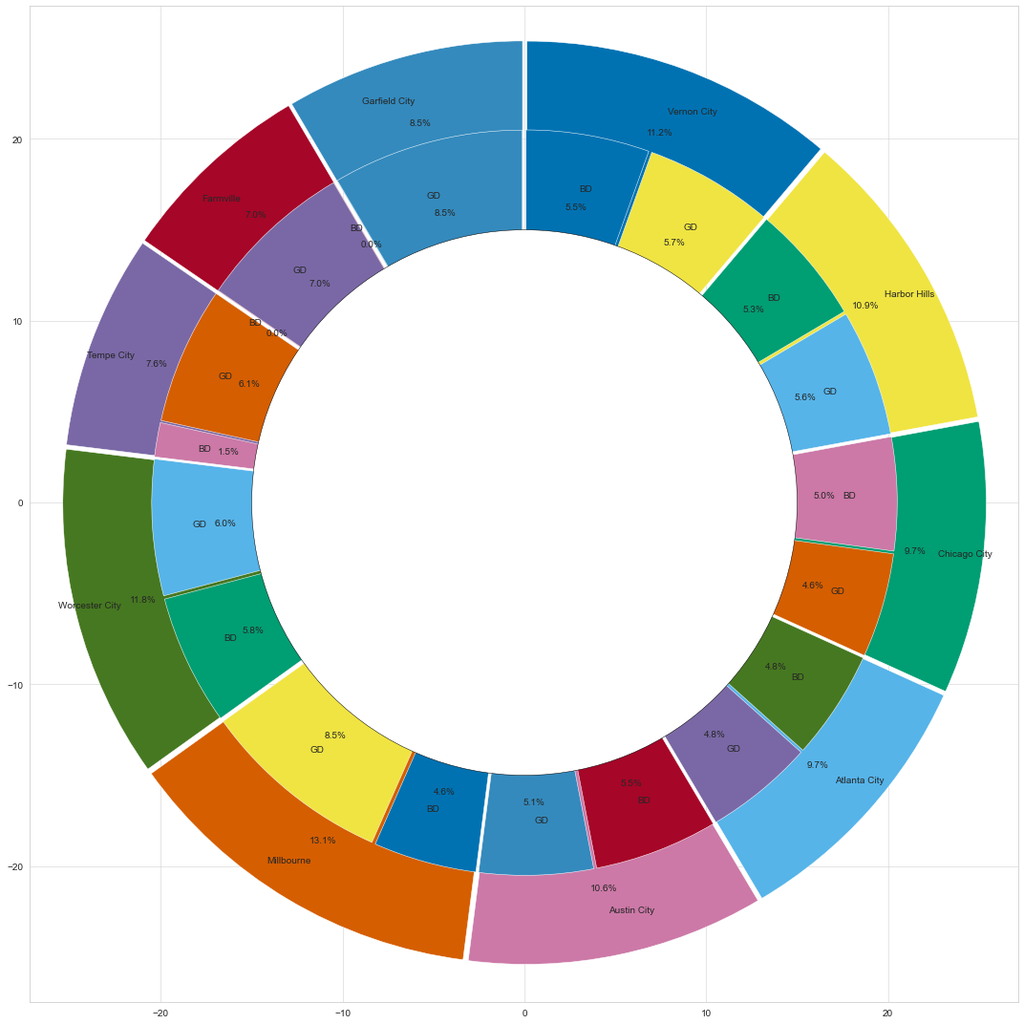

```python
labels = list(top_2500.place[:10])
debt = list(top_2500.debt[:10])

sns.set_style("whitegrid")

gd_bd = l3[:20]

plt.figure(figsize = (15, 15))

color_pal = plt.rcParams['axes.prop_cycle'].by_key()['color']
#color_cycle = cycle(plt.rcParams['axes.prop_cycle'].by_key()['color'])

plt.pie(debt, labels = labels, startangle = 90, frame = True, radius =25, autopct='%1.1f%%', pctdistance=0.85, labeldistance = 0.9, colors = color_pal, explode = explode)
plt.pie(gd_bd, labels = labels_D, startangle = 90, frame = True, radius = 20, autopct='%1.1f%%', pctdistance=0.80,  labeldistance = 0.85, colors = color_pal, explode = explode_bd)
centre_circle = plt.Circle((0,0),15,color='black', fc='white',linewidth=0.5)
fig = plt.gcf()
fig.gca().add_artist(centre_circle)

plt.axis('equal')
plt.tight_layout()
plt.show()
```

# Since it is difficult to show all 2500 locations, without compromising readability, I have limited my selection to "Top 10" cities.

# d) Create Box and whisker plot and analyze the distribution for 2nd mortgage, home equity, good debt, and bad debt for different cities.

```python
second_mortgage = list(top_2500.second_mortgage)
home_equity = list(top_2500.home_equity)

Good_Debt = list(top_2500.Good_Debt)
Bad_Debt = list(top_2500.Bad_Debt)
```

```python
top_2500['city'].value_counts()[:31].index
```

```
CategoricalIndex(['Chicago', 'Los Angeles', 'Washington', 'Brooklyn',
                  'Milwaukee', 'Aurora', 'Jacksonville', 'Denver', 'Charlotte',
                  'Las Vegas', 'Bronx', 'Baltimore', 'Minneapolis',
                  'Cincinnati', 'Long Beach', 'Colorado Springs', 'Sacramento',
                  'San Diego', 'New Orleans', 'Columbus', 'Lowell', 'Orlando',
                  'Portland', 'San Jose', 'Alexandria', 'Dallas', 'Atlanta',
                  'Littleton', 'Miami', 'Oakland', 'Houston'],
                 categories=['Abbeville', 'Aberdeen', 'Abilene', 'Abingdon', 'Abington', 'Accokeek', 'Acton', 'Acushnet', ...], ordered=False, dtype='category')
```

```python
cities = ['Chicago', 'Los Angeles', 'Washington', 'Brooklyn',
                  'Milwaukee', 'Aurora', 'Jacksonville', 'Denver', 'Charlotte',
                  'Las Vegas', 'Bronx', 'Baltimore', 'Minneapolis',
                  'Cincinnati', 'Long Beach', 'Colorado Springs', 'Sacramento',
                  'San Diego', 'New Orleans', 'Columbus', 'Lowell', 'Orlando',
                  'Portland', 'San Jose', 'Alexandria', 'Dallas', 'Atlanta',
                  'Littleton', 'Miami', 'Oakland', 'Houston']
```

```python
boxplot_df = top_2500[top_2500['city'].isin (cities)]
#rpt[rpt['STK_ID'].isin(stk_list)]
```

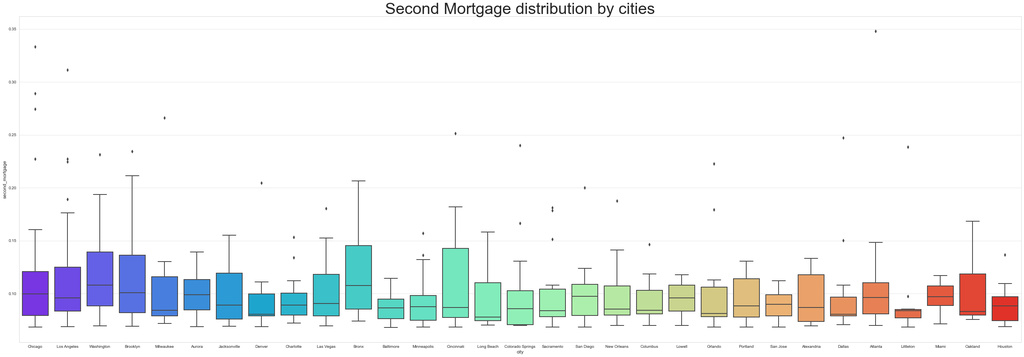

```python
sns.set_style("whitegrid")

plt.figure(figsize = (45, 15))
sns.boxplot(x='city',y='second_mortgage',data=boxplot_df,palette='rainbow', order = ['Chicago', 'Los Angeles', 'Washington', 'Brooklyn',
                  'Milwaukee', 'Aurora', 'Jacksonville', 'Denver', 'Charlotte',
                  'Las Vegas', 'Bronx', 'Baltimore', 'Minneapolis',
                  'Cincinnati', 'Long Beach', 'Colorado Springs', 'Sacramento',
                  'San Diego', 'New Orleans', 'Columbus', 'Lowell', 'Orlando',
                  'Portland', 'San Jose', 'Alexandria', 'Dallas', 'Atlanta',
                  'Littleton', 'Miami', 'Oakland', 'Houston']).set_title('Second Mortgage distribution by cities', fontsize = 40)
plt.show()
```

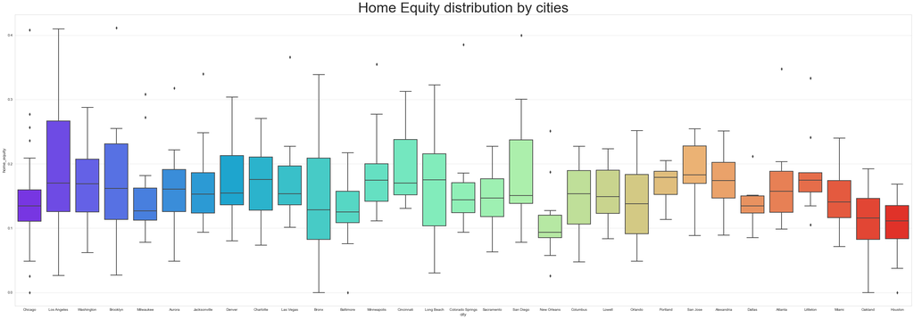

```python
sns.set_style("whitegrid")

plt.figure(figsize = (45, 15))
sns.boxplot(x='city',y='home_equity',data=boxplot_df,palette='rainbow', order = ['Chicago', 'Los Angeles', 'Washington', 'Brooklyn',
                  'Milwaukee', 'Aurora', 'Jacksonville', 'Denver', 'Charlotte',
                  'Las Vegas', 'Bronx', 'Baltimore', 'Minneapolis',
                  'Cincinnati', 'Long Beach', 'Colorado Springs', 'Sacramento',
                  'San Diego', 'New Orleans', 'Columbus', 'Lowell', 'Orlando',
                  'Portland', 'San Jose', 'Alexandria', 'Dallas', 'Atlanta',
                  'Littleton', 'Miami', 'Oakland', 'Houston']).set_title('Home Equity distribution by cities', fontsize = 40)
plt.show()
```

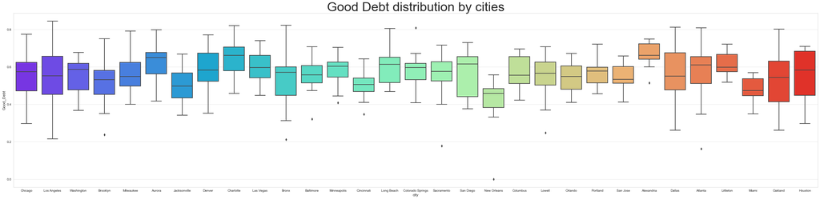

```python
sns.set_style("whitegrid")

plt.figure(figsize = (45, 10))
sns.boxplot(x='city',y='Good_Debt',data=boxplot_df,palette='rainbow', order = ['Chicago', 'Los Angeles', 'Washington', 'Brooklyn',
                  'Milwaukee', 'Aurora', 'Jacksonville', 'Denver', 'Charlotte',
                  'Las Vegas', 'Bronx', 'Baltimore', 'Minneapolis',
                  'Cincinnati', 'Long Beach', 'Colorado Springs', 'Sacramento',
                  'San Diego', 'New Orleans', 'Columbus', 'Lowell', 'Orlando',
                  'Portland', 'San Jose', 'Alexandria', 'Dallas', 'Atlanta',
                  'Littleton', 'Miami', 'Oakland', 'Houston']).set_title('Good Debt distribution by cities', fontsize = 40)
plt.show()
```

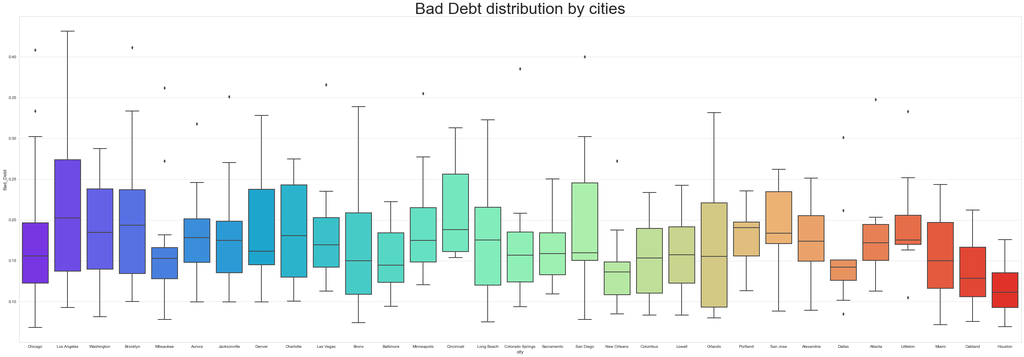

```python
sns.set_style("whitegrid")

plt.figure(figsize = (45, 15))
sns.boxplot(x='city',y='Bad_Debt',data=boxplot_df,palette='rainbow', order = ['Chicago', 'Los Angeles', 'Washington', 'Brooklyn',
                  'Milwaukee', 'Aurora', 'Jacksonville', 'Denver', 'Charlotte',
                  'Las Vegas', 'Bronx', 'Baltimore', 'Minneapolis',
                  'Cincinnati', 'Long Beach', 'Colorado Springs', 'Sacramento',
                  'San Diego', 'New Orleans', 'Columbus', 'Lowell', 'Orlando',
                  'Portland', 'San Jose', 'Alexandria', 'Dallas', 'Atlanta',
                  'Littleton', 'Miami', 'Oakland', 'Houston']).set_title('Bad Debt distribution by cities', fontsize = 40)
plt.show()
```

# Since it is difficult to show all 2500 locations, without compromising readability, I have limited my selection to "Top 31" cities.

# e) Create a collated income distribution chart for family income, house hold income, and remaining income.

```python
top_2500['remaining_income'] = top_2500['family_median'] - top_2500['hi_median']
```

```python
income_chart = round(top_2500[['city', 'hi_median', 'family_median', 'remaining_income']], 2)
income_chart
```

|  | city | hi_median | family_median | remaining_income |
| --- | --- | --- | --- | --- |
| 14014 | Passaic | 28053.0 | 29340.0 | 1287.0 |
| 3285 | Farmville | 23236.0 | 59954.0 | 36718.0 |
| 21706 | Scottsdale | 40883.0 | 59657.0 | 18774.0 |
| 11980 | Worcester | 29037.0 | 40476.0 | 11439.0 |
| 12896 | Philadelphia | 12881.0 | 50622.0 | 37741.0 |
| ... | ... | ... | ... | ... |
| 24443 | Manteca | 74648.0 | 76881.0 | 2233.0 |
| 8377 | Cutler Bay | 50832.0 | 52547.0 | 1715.0 |
| 16621 | Keller | 177847.0 | 177067.0 | -780.0 |
| 13987 | Middletown | 72585.0 | 77338.0 | 4753.0 |
| 14857 | Mays Landing | 52393.0 | 61947.0 | 9554.0 |

2563 rows × 4 columns

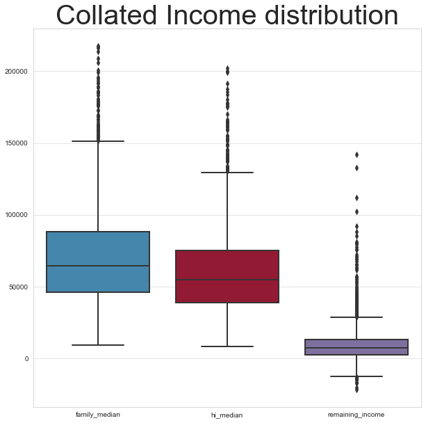

```python
sns.set_style("whitegrid")
plt.figure(figsize = (10, 10))
sns.boxplot(data=top_2500[['family_median', 'hi_median', 'remaining_income']], palette=color_pal).set_title('Collated Income distribution', fontsize = 40)
plt.show()
```

# Exploratory Data Analysis (EDA) ...Contd.,

# Project Task: Week 2

# 1. Perform EDA and come out with insights into population density and age. You may have to derive new fields (make sure to weight averages for accurate measurements): a) Use pop and ALand variables to create a new field called population density. b) Use male_age_median, female_age_median, male_pop, and female_pop to create a new field called median age. c) Visualize the findings using appropriate chart type

```python
train_df.head()
```

|  | UID | SUMLEVEL | COUNTYID | STATEID | state | state_ab | city | place | type | zip_code | area_code | lat | lng | ALand | AWater | pop | male_pop | female_pop | rent_mean | rent_median | rent_stdev | rent_sample_weight | rent_samples | rent_gt_10 | rent_gt_15 | rent_gt_20 | rent_gt_25 | rent_gt_30 | rent_gt_35 | … |
| --- | --- | --- | --- | --- | --- | --- | --- | --- | --- | --- | --- | --- | --- | --- | --- | --- | --- | --- | --- | --- | --- | --- | --- | --- | --- | --- | --- | --- | --- | --- |
| 0 | 267822 | 140 | 53 | 36 | New York | NY | Hamilton | Hamilton | City | 13346 | 315 | 42.840812 | -75.501524 | 202183361.0 | 1699120 | 5230 | 2612 | 2618 | 769.38638 | 784.0 | 232.63967 | 272.34441 | 362.0 | 0.86761 | 0.79155 | 0.59155 | 0.45634 | 0.42817 | 0.18592 | … |
| 1 | 246444 | 140 | 141 | 18 | Indiana | IN | South Bend | Roseland | City | 46616 | 574 | 41.701441 | -86.266614 | 1560828.0 | 100363 | 2633 | 1349 | 1284 | 804.87924 | 848.0 | 253.46747 | 312.58622 | 513.0 | 0.97410 | 0.93227 | 0.69920 | 0.69920 | 0.55179 | 0.41235 | … |
| 2 | 245683 | 140 | 63 | 18 | Indiana | IN | Danville | Danville | City | 46122 | 317 | 39.792202 | -86.515246 | 69561595.0 | 284193 | 6881 | 3643 | 3238 | 742.77365 | 703.0 | 323.39011 | 291.85520 | 378.0 | 0.95238 | 0.88624 | 0.79630 | 0.66667 | 0.39153 | 0.39153 | … |
| 3 | 279653 | 140 | 127 | 72 | Puerto Rico | PR | San Juan | Guaynabo | Urban | 927 | 787 | 18.396103 | -66.104169 | 1105793.0 | 0 | 2700 | 1141 | 1559 | 803.42018 | 782.0 | 297.39258 | 259.30316 | 368.0 | 0.94693 | 0.87151 | 0.69832 | 0.61732 | 0.51397 | 0.46927 | … |
| 4 | 247218 | 140 | 161 | 20 | Kansas | KS | Manhattan | Manhattan City | City | 66502 | 785 | 39.195573 | -96.569366 | 2554403.0 | 0 | 5637 | 2586 | 3051 | 938.56493 | 881.0 | 392.44096 | 1005.42886 | 1704.0 | 0.99286 | 0.98247 | 0.91688 | 0.84740 | 0.78247 | 0.60974 | … |

```python
density_eda_df = train_df[['state', 'city', 'place', 'ALand', 'pop', 'male_age_median', 'female_age_median', 'male_pop', 'female_pop']]
density_eda_df.head()
```

|  | state | city | place | ALand | pop | male_age_median | female_age_median | male_pop | female_pop |
| --- | --- | --- | --- | --- | --- | --- | --- | --- | --- |
| 0 | New York | Hamilton | Hamilton | 202183361.0 | 5230 | 44.00000 | 45.33333 | 2612 | 2618 |
| 1 | Indiana | South Bend | Roseland | 1560828.0 | 2633 | 32.00000 | 37.58333 | 1349 | 1284 |
| 2 | Indiana | Danville | Danville | 69561595.0 | 6881 | 40.83333 | 42.83333 | 3643 | 3238 |
| 3 | Puerto Rico | San Juan | Guaynabo | 1105793.0 | 2700 | 48.91667 | 50.58333 | 1141 | 1559 |
| 4 | Kansas | Manhattan | Manhattan City | 2554403.0 | 5637 | 22.41667 | 21.58333 | 2586 | 3051 |

```python
density_eda_df['pop_density'] = density_eda_df['pop'] / density_eda_df['ALand']
density_eda_df.head()
```

|  | state | city | place | ALand | pop | male_age_median | female_age_median | male_pop | female_pop | pop_density |
| --- | --- | --- | --- | --- | --- | --- | --- | --- | --- | --- |
| 0 | New York | Hamilton | Hamilton | 202183361.0 | 5230 | 44.00000 | 45.33333 | 2612 | 2618 | 0.000026 |
| 1 | Indiana | South Bend | Roseland | 1560828.0 | 2633 | 32.00000 | 37.58333 | 1349 | 1284 | 0.001687 |
| 2 | Indiana | Danville | Danville | 69561595.0 | 6881 | 40.83333 | 42.83333 | 3643 | 3238 | 0.000099 |
| 3 | Puerto Rico | San Juan | Guaynabo | 1105793.0 | 2700 | 48.91667 | 50.58333 | 1141 | 1559 | 0.002442 |
| 4 | Kansas | Manhattan | Manhattan City | 2554403.0 | 5637 | 22.41667 | 21.58333 | 2586 | 3051 | 0.002207 |

```python
density_eda_df['median_age'] = (density_eda_df['male_age_median'] *  density_eda_df['male_pop'] + density_eda_df['female_age_median'] *  density_eda_df['female_pop'])  / density_eda_df['pop']
density_eda_df.head()
```

|  | state | city | place | ALand | pop | male_age_median | female_age_median | male_pop | female_pop | pop_density | median_age |
| --- | --- | --- | --- | --- | --- | --- | --- | --- | --- | --- | --- |
| 0 | New York | Hamilton | Hamilton | 202183361.0 | 5230 | 44.00000 | 45.33333 | 2612 | 2618 | 0.000026 | 44.667430 |
| 1 | Indiana | South Bend | Roseland | 1560828.0 | 2633 | 32.00000 | 37.58333 | 1349 | 1284 | 0.001687 | 34.722748 |
| 2 | Indiana | Danville | Danville | 69561595.0 | 6881 | 40.83333 | 42.83333 | 3643 | 3238 | 0.000099 | 41.774472 |
| 3 | Puerto Rico | San Juan | Guaynabo | 1105793.0 | 2700 | 48.91667 | 50.58333 | 1141 | 1559 | 0.002442 | 49.879012 |
| 4 | Kansas | Manhattan | Manhattan City | 2554403.0 | 5637 | 22.41667 | 21.58333 | 2586 | 3051 | 0.002207 | 21.965629 |

```python
density_eda_df.nlargest(300, 'pop_density')
```

|  | state | city | place | ALand | pop | male_age_median | female_age_median | male_pop | female_pop | pop_density | median_age |
| --- | --- | --- | --- | --- | --- | --- | --- | --- | --- | --- | --- |
| 21050 | New York | New York | New York City | 182091.0 | 13162 | 38.83333 | 34.66667 | 5597 | 7565 | 0.072283 | 36.438498 |
| 10251 | New York | New York | Mount Vernon City | 169349.0 | 12189 | 33.25000 | 35.33333 | 6110 | 6079 | 0.071976 | 34.289016 |
| 1546 | New York | New York | New York City | 183653.0 | 12427 | 37.00000 | 41.83333 | 5425 | 7002 | 0.067666 | 39.723342 |
| 23760 | New York | New York | New York City | 181779.0 | 11688 | 39.25000 | 41.50000 | 5011 | 6677 | 0.064298 | 40.535357 |
| 13022 | New York | Bronx | Mount Vernon City | 67355.0 | 4229 | 27.75000 | 26.66667 | 1932 | 2297 | 0.062787 | 27.161585 |
| ... | ... | ... | ... | ... | ... | ... | ... | ... | ... | ... | ... |
| 14705 | New Jersey | Guttenberg | Guttenberg | 178469.0 | 3715 | 33.66667 | 34.00000 | 1893 | 1822 | 0.020816 | 33.830150 |
| 706 | New York | Brooklyn | New York City | 184193.0 | 3829 | 29.58333 | 34.66667 | 1824 | 2005 | 0.020788 | 32.245147 |
| 16852 | New Jersey | Jersey City | Hoboken City | 219021.0 | 4545 | 30.50000 | 32.41667 | 2330 | 2215 | 0.020751 | 31.434087 |
| 8015 | New York | Brooklyn | New York City | 207813.0 | 4304 | 44.00000 | 47.00000 | 2196 | 2108 | 0.020711 | 45.469331 |
| 19946 | New York | Brooklyn | New York City | 165897.0 | 3418 | 42.33333 | 38.83333 | 1468 | 1950 | 0.020603 | 40.336548 |

300 rows × 11 columns

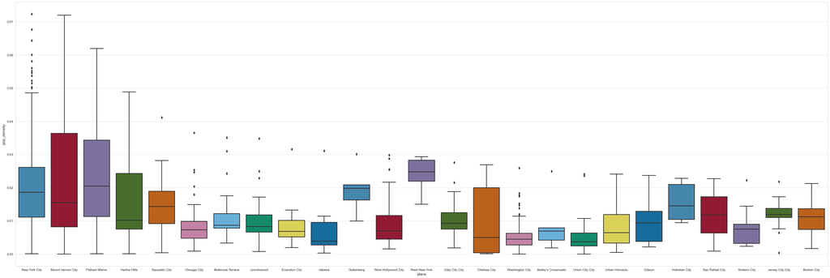

```python
sns.set_style("whitegrid")
plt.figure(figsize = (45, 15))
sns.boxplot(x = 'place', y = 'pop_density', data=density_eda_df.nlargest(26585, 'pop_density'), palette=color_pal, order = ['New York City',
 'Mount Vernon City',
 'Pelham Manor',
 'Harbor Hills',
 'Sausalito City',
 'Chicago City',
 'Bellerose Terrace',
 'Lincolnwood',
 'Evanston City',
 'Halawa',
 'Guttenberg',
 'West Hollywood City',
 'West New York',
 'Daly City City',
 'Chelsea City',
 'Washington City',
 "Bailey's Crossroads",
 'Union City City',
 'Urban Honolulu',
 'Colwyn',
 'Hoboken City',
 'San Rafael City',
 'Yonkers City',
 'Jersey City City',
 'Boston City'])
plt.show()
```

```python
list(density_eda_df.nsmallest(450, 'pop_density').state.unique())
```

```
['Alaska',
 'Montana',
 'Utah',
 'Oregon',
 'Nevada',
 'Colorado',
 'Idaho',
 'California',
 'New Mexico',
 'Maine',
 'South Dakota',
 'Wyoming',
 'Nebraska',
 'Texas',
 'Kansas',
 'North Dakota',
 'Arizona',
 'Washington',
 'New York',
 'Oklahoma',
 'Minnesota',
 'Louisiana',
 'Michigan',
 'Florida',
 'Wisconsin',
 'Mississippi',
 'New Hampshire',
 'Georgia',
 'Missouri',
 'Virginia',
 'Alabama',
 'Arkansas']
```